# Overview

#### In Retail and E-Commerce (B2C) and in B2B, one of the key elements shaping the business strategy of a firm would be understanding of customer behaviour.

#### Such understanding would in turn help direct marketing to support this customer and improve the product offering efficiently.

### In business, there are some golden rules that everyone needs to know:

## **"80% percent of our business comes from 20% of our customers."**

## **"It costs 10 times less to sell to an existing customer than to find a new customer."**

### So, it’s important to understand who your top customers are that give consistent and increasing revenue streams for your business.

### One of the simple and effective methodologies which are generally used in calculating customer value over a time frame is RFM

[figure not shown]

# Business Understanding

## Business Problem

### An e-commerce company wants to segment its customers and determine marketing strategies towards these segments.

### To achieve this objective,

### we will define the purchase behavior of customers,

### create different segments based on these behaviors, and

### suggest some valuable marketing strategies for each segment.

## Data Set Information:

### This Online Retail II data set contains all the transactions occurring for a UK-based and registered, non-store online retail between 01/12/2009 and 09/12/2011.The company mainly sells unique all-occasion gift-ware. Many customers of the company are wholesalers.

## Attribute Information:

### **InvoiceNo:**

#### Invoice number. Nominal. A 6-digit integral number uniquely assigned to each transaction. If this code starts with the letter 'c', it indicates a cancellation.

### **StockCode:**

#### Product (item) code. Nominal. A 5-digit integral number uniquely assigned to each distinct product.

### **Description:**

#### Product (item) name. Nominal.

### **Quantity:**

#### The quantities of each product (item) per transaction. Numeric.

### **InvoiceDate:**

#### Invoice date and time. Numeric. The day and time when a transaction was generated.

### **UnitPrice:**

#### Unit price. Numeric. Product price per unit in sterling (Â£).

### **CustomerID:**

#### Customer number. Nominal. A 5-digit integral number uniquely assigned to each customer.

### **Country:**

#### Country name. Nominal. The name of the country where a customer resides.

# **Data Understanding (Data Exploration)**

```python
#importing needed packages

import numpy as np
import pandas as pd
import matplotlib.pyplot as plt

pd.options.mode.chained_assignment = None


#Uploading the Excel file to the notebook
xl_file = pd.ExcelFile('online_retail_II.xlsx')
df1 = pd.read_excel(xl_file, 'Year 2009-2010')
df2 = pd.read_excel(xl_file, 'Year 2010-2011')
df = pd.concat([df1, df2])
```

```python
# showing First five rows of the dataframe
df.head()
```

|  | Invoice | StockCode | Description | Quantity | InvoiceDate | Price | Customer ID | Country |
| --- | --- | --- | --- | --- | --- | --- | --- | --- |
| 0 | 489434 | 85048 | 15CM CHRISTMAS GLASS BALL 20 LIGHTS | 12 | 2009-12-01 07:45:00 | 6.95 | 13085.0 | United Kingdom |
| 1 | 489434 | 79323P | PINK CHERRY LIGHTS | 12 | 2009-12-01 07:45:00 | 6.75 | 13085.0 | United Kingdom |
| 2 | 489434 | 79323W | WHITE CHERRY LIGHTS | 12 | 2009-12-01 07:45:00 | 6.75 | 13085.0 | United Kingdom |
| 3 | 489434 | 22041 | RECORD FRAME 7" SINGLE SIZE | 48 | 2009-12-01 07:45:00 | 2.10 | 13085.0 | United Kingdom |
| 4 | 489434 | 21232 | STRAWBERRY CERAMIC TRINKET BOX | 24 | 2009-12-01 07:45:00 | 1.25 | 13085.0 | United Kingdom |

```python
#Check how many rows and columns we have
print('Number of Records:')
print(df.shape[0])
print('Number of Columns:')
print(df.shape[1])
```

```
Number of Records:
1067371
Number of Columns:
8
```

```python
#Types of columns
print('Types of columns:')
df.dtypes
```

```
Types of columns:
```

```
Invoice                object
StockCode              object
Description            object
Quantity                int64
InvoiceDate    datetime64[ns]
Price                 float64
Customer ID           float64
Country                object
dtype: object
```

```python
#Exploring some statistics of numerical columns
print('Description of Numerical columns: \n',df.describe(), '\n')

#Checking the number of Null values in each column
print('Number of Missing Values:\n',df.isnull().sum())
```

```
Description of Numerical columns:
            Quantity         Price    Customer ID
count  1.067371e+06  1.067371e+06  824364.000000
mean   9.938898e+00  4.649388e+00   15324.638504
std    1.727058e+02  1.235531e+02    1697.464450
min   -8.099500e+04 -5.359436e+04   12346.000000
25%    1.000000e+00  1.250000e+00   13975.000000
50%    3.000000e+00  2.100000e+00   15255.000000
75%    1.000000e+01  4.150000e+00   16797.000000
max    8.099500e+04  3.897000e+04   18287.000000

Number of Missing Values:
 Invoice             0
StockCode           0
Description      4382
Quantity            0
InvoiceDate         0
Price               0
Customer ID    243007
Country             0
dtype: int64
```

```python
#quantity and price are negatives and zeros
```

```python
df[(df['Price'] <= 0)]
```

|  | Invoice | StockCode | Description | Quantity | InvoiceDate | Price | Customer ID | Country |
| --- | --- | --- | --- | --- | --- | --- | --- | --- |
| 263 | 489464 | 21733 | 85123a mixed | -96 | 2009-12-01 10:52:00 | 0.0 | NaN | United Kingdom |
| 283 | 489463 | 71477 | short | -240 | 2009-12-01 10:52:00 | 0.0 | NaN | United Kingdom |
| 284 | 489467 | 85123A | 21733 mixed | -192 | 2009-12-01 10:53:00 | 0.0 | NaN | United Kingdom |
| 470 | 489521 | 21646 | NaN | -50 | 2009-12-01 11:44:00 | 0.0 | NaN | United Kingdom |
| 3114 | 489655 | 20683 | NaN | -44 | 2009-12-01 17:26:00 | 0.0 | NaN | United Kingdom |
| ... | ... | ... | ... | ... | ... | ... | ... | ... |
| 536981 | 581234 | 72817 | NaN | 27 | 2011-12-08 10:33:00 | 0.0 | NaN | United Kingdom |
| 538504 | 581406 | 46000M | POLYESTER FILLER PAD 45x45cm | 240 | 2011-12-08 13:58:00 | 0.0 | NaN | United Kingdom |
| 538505 | 581406 | 46000S | POLYESTER FILLER PAD 40x40cm | 300 | 2011-12-08 13:58:00 | 0.0 | NaN | United Kingdom |
| 538554 | 581408 | 85175 | NaN | 20 | 2011-12-08 14:06:00 | 0.0 | NaN | United Kingdom |
| 538925 | 581422 | 23169 | smashed | -235 | 2011-12-08 15:24:00 | 0.0 | NaN | United Kingdom |

6207 rows × 8 columns

```python
#Some invoices are cancelled and some are adjusted
```

```python
df[df["Invoice"].str.startswith("A", na=False)]
```

|  | Invoice | StockCode | Description | Quantity | InvoiceDate | Price | Customer ID | Country |
| --- | --- | --- | --- | --- | --- | --- | --- | --- |
| 179403 | A506401 | B | Adjust bad debt | 1 | 2010-04-29 13:36:00 | -53594.36 | NaN | United Kingdom |
| 276274 | A516228 | B | Adjust bad debt | 1 | 2010-07-19 11:24:00 | -44031.79 | NaN | United Kingdom |
| 403472 | A528059 | B | Adjust bad debt | 1 | 2010-10-20 12:04:00 | -38925.87 | NaN | United Kingdom |
| 299982 | A563185 | B | Adjust bad debt | 1 | 2011-08-12 14:50:00 | 11062.06 | NaN | United Kingdom |
| 299983 | A563186 | B | Adjust bad debt | 1 | 2011-08-12 14:51:00 | -11062.06 | NaN | United Kingdom |
| 299984 | A563187 | B | Adjust bad debt | 1 | 2011-08-12 14:52:00 | -11062.06 | NaN | United Kingdom |

```python
df[df["Invoice"].str.startswith("C", na=False)]
```

|  | Invoice | StockCode | Description | Quantity | InvoiceDate | Price | Customer ID | Country |
| --- | --- | --- | --- | --- | --- | --- | --- | --- |
| 178 | C489449 | 22087 | PAPER BUNTING WHITE LACE | -12 | 2009-12-01 10:33:00 | 2.95 | 16321.0 | Australia |
| 179 | C489449 | 85206A | CREAM FELT EASTER EGG BASKET | -6 | 2009-12-01 10:33:00 | 1.65 | 16321.0 | Australia |
| 180 | C489449 | 21895 | POTTING SHED SOW 'N' GROW SET | -4 | 2009-12-01 10:33:00 | 4.25 | 16321.0 | Australia |
| 181 | C489449 | 21896 | POTTING SHED TWINE | -6 | 2009-12-01 10:33:00 | 2.10 | 16321.0 | Australia |
| 182 | C489449 | 22083 | PAPER CHAIN KIT RETRO SPOT | -12 | 2009-12-01 10:33:00 | 2.95 | 16321.0 | Australia |
| ... | ... | ... | ... | ... | ... | ... | ... | ... |
| 540449 | C581490 | 23144 | ZINC T-LIGHT HOLDER STARS SMALL | -11 | 2011-12-09 09:57:00 | 0.83 | 14397.0 | United Kingdom |
| 541541 | C581499 | M | Manual | -1 | 2011-12-09 10:28:00 | 224.69 | 15498.0 | United Kingdom |
| 541715 | C581568 | 21258 | VICTORIAN SEWING BOX LARGE | -5 | 2011-12-09 11:57:00 | 10.95 | 15311.0 | United Kingdom |
| 541716 | C581569 | 84978 | HANGING HEART JAR T-LIGHT HOLDER | -1 | 2011-12-09 11:58:00 | 1.25 | 17315.0 | United Kingdom |
| 541717 | C581569 | 20979 | 36 PENCILS TUBE RED RETROSPOT | -5 | 2011-12-09 11:58:00 | 1.25 | 17315.0 | United Kingdom |

19494 rows × 8 columns

# Data Prepration

## Cleaning

```python
#Removing records with cancelled & Adjusted orders
df = df[~df["Invoice"].str.startswith(('C', 'A'), na=False)]
df.shape
```

```
(1047871, 8)
```

```python
#slicing the dataframe to conntain only the rows with data in the customer id column
df_cust_filter = df[pd.notnull(df['Customer ID'])]
df_cust_filter.shape
```

```
(805620, 8)
```

```python
#Checking if there is any null values
df_cust_filter.isnull().sum()
```

```
Invoice        0
StockCode      0
Description    0
Quantity       0
InvoiceDate    0
Price          0
Customer ID    0
Country        0
dtype: int64
```

```python
#Removing records with price & quantity equal zero or less.
df_filtered = df_cust_filter[(df_cust_filter['Quantity'] > 0) & (df_cust_filter['Price'] > 0)]
df_filtered.shape
```

```
(805549, 8)
```

```python
# checking types of columns and number of records
df_filtered.info()
```

```
<class 'pandas.core.frame.DataFrame'>
Int64Index: 805549 entries, 0 to 541909
Data columns (total 8 columns):
 #   Column       Non-Null Count   Dtype
---  ------       --------------   -----
 0   Invoice      805549 non-null  object
 1   StockCode    805549 non-null  object
 2   Description  805549 non-null  object
 3   Quantity     805549 non-null  int64
 4   InvoiceDate  805549 non-null  datetime64[ns]
 5   Price        805549 non-null  float64
 6   Customer ID  805549 non-null  float64
 7   Country      805549 non-null  object
dtypes: datetime64[ns](1), float64(2), int64(1), object(4)
memory usage: 55.3+ MB
```

## Transforming

```python
#Adding a total price column to use it developing metrics
df_filtered['TotalPrice'] = df_filtered['Quantity'] * df_filtered['Price']
df_filtered
```

|  | Invoice | StockCode | Description | Quantity | InvoiceDate | Price | Customer ID | Country | TotalPrice |
| --- | --- | --- | --- | --- | --- | --- | --- | --- | --- |
| 0 | 489434 | 85048 | 15CM CHRISTMAS GLASS BALL 20 LIGHTS | 12 | 2009-12-01 07:45:00 | 6.95 | 13085.0 | United Kingdom | 83.40 |
| 1 | 489434 | 79323P | PINK CHERRY LIGHTS | 12 | 2009-12-01 07:45:00 | 6.75 | 13085.0 | United Kingdom | 81.00 |
| 2 | 489434 | 79323W | WHITE CHERRY LIGHTS | 12 | 2009-12-01 07:45:00 | 6.75 | 13085.0 | United Kingdom | 81.00 |
| 3 | 489434 | 22041 | RECORD FRAME 7" SINGLE SIZE | 48 | 2009-12-01 07:45:00 | 2.10 | 13085.0 | United Kingdom | 100.80 |
| 4 | 489434 | 21232 | STRAWBERRY CERAMIC TRINKET BOX | 24 | 2009-12-01 07:45:00 | 1.25 | 13085.0 | United Kingdom | 30.00 |
| ... | ... | ... | ... | ... | ... | ... | ... | ... | ... |
| 541905 | 581587 | 22899 | CHILDREN'S APRON DOLLY GIRL | 6 | 2011-12-09 12:50:00 | 2.10 | 12680.0 | France | 12.60 |
| 541906 | 581587 | 23254 | CHILDRENS CUTLERY DOLLY GIRL | 4 | 2011-12-09 12:50:00 | 4.15 | 12680.0 | France | 16.60 |
| 541907 | 581587 | 23255 | CHILDRENS CUTLERY CIRCUS PARADE | 4 | 2011-12-09 12:50:00 | 4.15 | 12680.0 | France | 16.60 |
| 541908 | 581587 | 22138 | BAKING SET 9 PIECE RETROSPOT | 3 | 2011-12-09 12:50:00 | 4.95 | 12680.0 | France | 14.85 |
| 541909 | 581587 | POST | POSTAGE | 1 | 2011-12-09 12:50:00 | 18.00 | 12680.0 | France | 18.00 |

805549 rows × 9 columns

```python
#Extracting a separate date column from the InvoiceDate column
df_filtered['Date'] = pd.DatetimeIndex(df_filtered['InvoiceDate']).date
```

```python
df_filtered.head()
```

|  | Invoice | StockCode | Description | Quantity | InvoiceDate | Price | Customer ID | Country | TotalPrice | Date |
| --- | --- | --- | --- | --- | --- | --- | --- | --- | --- | --- |
| 0 | 489434 | 85048 | 15CM CHRISTMAS GLASS BALL 20 LIGHTS | 12 | 2009-12-01 07:45:00 | 6.95 | 13085.0 | United Kingdom | 83.4 | 2009-12-01 |
| 1 | 489434 | 79323P | PINK CHERRY LIGHTS | 12 | 2009-12-01 07:45:00 | 6.75 | 13085.0 | United Kingdom | 81.0 | 2009-12-01 |
| 2 | 489434 | 79323W | WHITE CHERRY LIGHTS | 12 | 2009-12-01 07:45:00 | 6.75 | 13085.0 | United Kingdom | 81.0 | 2009-12-01 |
| 3 | 489434 | 22041 | RECORD FRAME 7" SINGLE SIZE | 48 | 2009-12-01 07:45:00 | 2.10 | 13085.0 | United Kingdom | 100.8 | 2009-12-01 |
| 4 | 489434 | 21232 | STRAWBERRY CERAMIC TRINKET BOX | 24 | 2009-12-01 07:45:00 | 1.25 | 13085.0 | United Kingdom | 30.0 | 2009-12-01 |

```python
#Checking the date range of orders (the first and last ever purchase)
first_purchase = df_filtered['Date'].min()
last_purchase = df_filtered['Date'].max()
print(first_purchase)
print(last_purchase)
```

```
2009-12-01
2011-12-09
```

```python
#Setting a date to use it in Recency calculation in RFM as it's a today's date.
import datetime as dt
last_date = dt.date(2011,12,10)
print(last_date)
```

```
2011-12-10
```

# Clustering (Segmetation) Analysis based on RFM

## What is RFM?

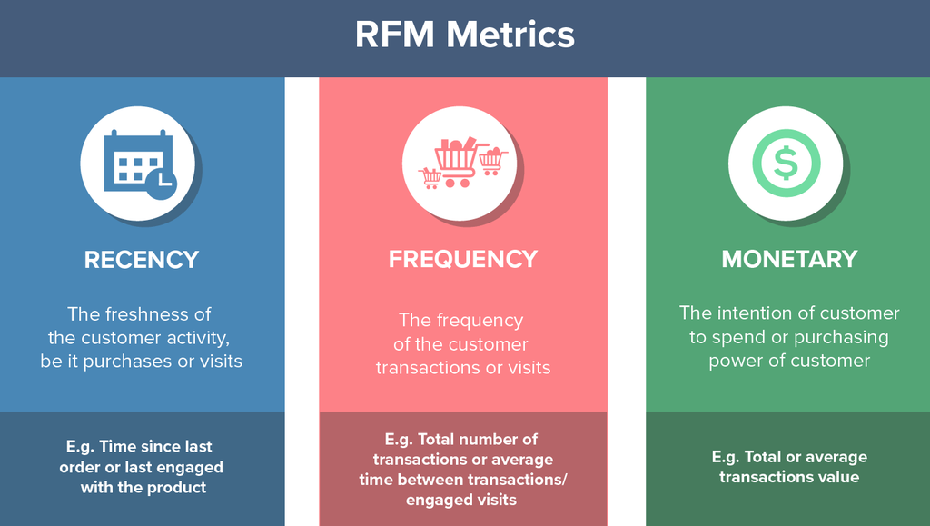

```python
#Creating a new dataframe only for the RFM analysis
#First, grouping the dataframe based on Customer IDs, then Creating lastpurchase column,
#then calculate the first factor of RFM (Recency)

rfm1 = df_filtered.groupby(by='Customer ID', as_index=False)['Date'].max()
rfm1.columns = ['Customer ID','Lastpurchase']
rfm1['Recency'] = rfm1['Lastpurchase'].apply(lambda x: (last_date - x).days)
rfm1.head()
```

|  | Customer ID | Lastpurchase | Recency |
| --- | --- | --- | --- |
| 0 | 12346.0 | 2011-01-18 | 326 |
| 1 | 12347.0 | 2011-12-07 | 3 |
| 2 | 12348.0 | 2011-09-25 | 76 |
| 3 | 12349.0 | 2011-11-21 | 19 |
| 4 | 12350.0 | 2011-02-02 | 311 |

```python
#Dropping duplicates based on the invoice number and the customer id
df_filtered.drop_duplicates(subset=['Invoice', 'Customer ID'], keep="first", inplace=True)

#Creating Frequency column
rfm2 = df_filtered.groupby(by=['Customer ID'], as_index=False)['Invoice'].count()
rfm2.columns = ['Customer ID','Frequency']
rfm2.head()
```

|  | Customer ID | Frequency |
| --- | --- | --- |
| 0 | 12346.0 | 12 |
| 1 | 12347.0 | 8 |
| 2 | 12348.0 | 5 |
| 3 | 12349.0 | 4 |
| 4 | 12350.0 | 1 |

```python
# Creating Monetary column - Summing the amount of money
rfm3 = df_filtered.groupby(by='Customer ID',as_index=False)['TotalPrice'].sum()
rfm3.columns = ['Customer ID','Monetary']
rfm3.head()
```

|  | Customer ID | Monetary |
| --- | --- | --- |
| 0 | 12346.0 | 77397.84 |
| 1 | 12347.0 | 180.86 |
| 2 | 12348.0 | 344.56 |
| 3 | 12349.0 | 252.65 |
| 4 | 12350.0 | 25.20 |

```python
#merge all seprated RFM factors together
from functools import reduce
df_rfm = reduce(lambda x,y: pd.merge(x,y, on='Customer ID', how='outer'), [rfm1, rfm2, rfm3])

df_rfm.head()
```

|  | Customer ID | Lastpurchase | Recency | Frequency | Monetary |
| --- | --- | --- | --- | --- | --- |
| 0 | 12346.0 | 2011-01-18 | 326 | 12 | 77397.84 |
| 1 | 12347.0 | 2011-12-07 | 3 | 8 | 180.86 |
| 2 | 12348.0 | 2011-09-25 | 76 | 5 | 344.56 |
| 3 | 12349.0 | 2011-11-21 | 19 | 4 | 252.65 |
| 4 | 12350.0 | 2011-02-02 | 311 | 1 | 25.20 |

```python
#splitting RFM elements into 4 parts and Setting a score for each part depending on their weight/value.

df_rfm["RecencyScore"] = pd.qcut(df_rfm["Recency"], 4, labels = [4,3,2,1])
df_rfm["FrequencyScore"] = pd.qcut(df_rfm["Frequency"].rank(method = "first"), 4, labels = [1,2,3,4])
df_rfm["MonetaryScore"] = pd.qcut(df_rfm["Monetary"], 4, labels = [1,2,3,4])
df_rfm.head()
```

|  | Customer ID | Lastpurchase | Recency | Frequency | Monetary | RecencyScore | FrequencyScore | MonetaryScore |
| --- | --- | --- | --- | --- | --- | --- | --- | --- |
| 0 | 12346.0 | 2011-01-18 | 326 | 12 | 77397.84 | 2 | 4 | 4 |
| 1 | 12347.0 | 2011-12-07 | 3 | 8 | 180.86 | 4 | 4 | 3 |
| 2 | 12348.0 | 2011-09-25 | 76 | 5 | 344.56 | 3 | 3 | 4 |
| 3 | 12349.0 | 2011-11-21 | 19 | 4 | 252.65 | 4 | 3 | 4 |
| 4 | 12350.0 | 2011-02-02 | 311 | 1 | 25.20 | 2 | 1 | 2 |

```python
#Converting the three columns of RFM RecencyScore, FrequencyScore and MonetaryScore to use them in summing later
df_rfm[['RecencyScore', 'FrequencyScore', 'MonetaryScore']] = df_rfm[['RecencyScore', 'FrequencyScore', 'MonetaryScore']].apply(pd.to_numeric)
df_rfm.dtypes
```

```
Customer ID       float64
Lastpurchase       object
Recency             int64
Frequency           int64
Monetary          float64
RecencyScore        int64
FrequencyScore      int64
MonetaryScore       int64
dtype: object
```

```python
#Concatenating all RFM score columns in one column per customer as a string  to use it in checking the sizes of each RFM combination
df_rfm["RFMScore"] = (df_rfm['RecencyScore'].astype(str) + df_rfm['FrequencyScore'].astype(str) +
                      df_rfm['MonetaryScore'].astype(str))
```

```python
#summing all RFM scores per customer to use in checking the sizes of each RFM total based on the sum of scores and other metrics
df_rfm["RFMScoreSum"] = df_rfm[['RecencyScore', 'FrequencyScore', 'MonetaryScore']].sum(axis=1)
```

```python
df_rfm.head()
```

|  | Customer ID | Lastpurchase | Recency | Frequency | Monetary | RecencyScore | FrequencyScore | MonetaryScore | RFMScore | RFMScoreSum |
| --- | --- | --- | --- | --- | --- | --- | --- | --- | --- | --- |
| 0 | 12346.0 | 2011-01-18 | 326 | 12 | 77397.84 | 2 | 4 | 4 | 244 | 10 |
| 1 | 12347.0 | 2011-12-07 | 3 | 8 | 180.86 | 4 | 4 | 3 | 443 | 11 |
| 2 | 12348.0 | 2011-09-25 | 76 | 5 | 344.56 | 3 | 3 | 4 | 334 | 10 |
| 3 | 12349.0 | 2011-11-21 | 19 | 4 | 252.65 | 4 | 3 | 4 | 434 | 11 |
| 4 | 12350.0 | 2011-02-02 | 311 | 1 | 25.20 | 2 | 1 | 2 | 212 | 5 |

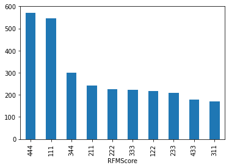

```python
#check the biggest segements in size based on each RFM combination
df_rfm.groupby("RFMScore").size().sort_values(ascending=False)[:10].plot(kind='bar')
plt.show()
```

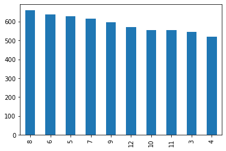

```
8     660
6     636
5     627
7     616
9     595
12    572
10    554
11    554
3     545
4     519
Name: RFMScoreSum, dtype: int64
```

```python
# Check the number of customers of each total unique sum of scores
df_rfm["RFMScoreSum"].value_counts().plot(kind='bar')
plt.show();
print(df_rfm["RFMScoreSum"].value_counts())
```

```python
#Check the size and the average of each group based on each total unique sum of scores
df_rfm.groupby("RFMScoreSum").agg({'RecencyScore': 'mean', 'FrequencyScore': 'mean', 'MonetaryScore': ['mean', 'count'] })
```

| RFMScoreSum | RecencyScore mean | FrequencyScore mean | MonetaryScore mean | MonetaryScore count |
| --- | --- | --- | --- | --- |
| 3 | 1.000000 | 1.000000 | 1.000000 | 545 |
| 4 | 1.468208 | 1.240848 | 1.290944 | 519 |
| 5 | 1.826156 | 1.551834 | 1.622010 | 627 |
| 6 | 2.130503 | 1.841195 | 2.028302 | 636 |
| 7 | 2.373377 | 2.318182 | 2.308442 | 616 |
| 8 | 2.696970 | 2.657576 | 2.645455 | 660 |
| 9 | 2.887395 | 3.060504 | 3.052101 | 595 |
| 10 | 3.164260 | 3.505415 | 3.330325 | 554 |
| 11 | 3.456679 | 3.842960 | 3.700361 | 554 |
| 12 | 4.000000 | 4.000000 | 4.000000 | 572 |

# Ranked Segments

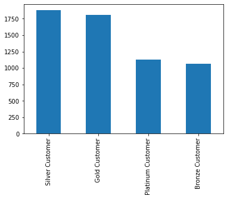

```python
# Setting general four segments of all customers based on total sum of scores.
df_rfm["Ranked_segm"]=np.where(df_rfm['RFMScoreSum'] > 10 ,"Platinum Customer",
                               np.where(df_rfm['RFMScoreSum'] > 7 ,"Gold Customer",
                                        np.where(df_rfm['RFMScoreSum'] > 4 ,"Silver Customer", 'Bronze Customer')))
df_rfm["Ranked_segm"].value_counts().plot(kind='bar')
plt.show()
```

```python
#Check the average value for the actual RFM scores per each segement , then check the size of each segment
df_rfm.groupby("Ranked_segm").agg({'RecencyScore': 'mean', 'FrequencyScore': 'mean', 'MonetaryScore': ['mean', 'count'] }).round(2)
```

| Ranked_segm | RecencyScore mean | FrequencyScore mean | MonetaryScore mean | MonetaryScore count |
| --- | --- | --- | --- | --- |
| Bronze Customer | 1.23 | 1.12 | 1.14 | 1064 |
| Gold Customer | 2.90 | 3.05 | 2.99 | 1809 |
| Platinum Customer | 3.73 | 3.92 | 3.85 | 1126 |
| Silver Customer | 2.11 | 1.90 | 1.98 | 1879 |

# Extreme Segments

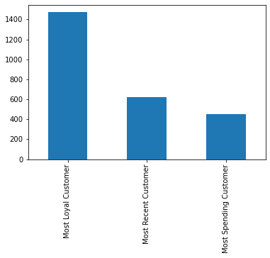

```
NOT Extreme Segment       3337
Most Loyal Customer       1470
Most Recent Customer       621
Most Spending Customer     450
Name: Extreme_segm, dtype: int64
```

```python
#Adding Extreme_segm column to segment the customers in a way to highlight only the most recent, frequent or spending customers.
df_rfm["Extreme_segm"]=np.where(df_rfm['FrequencyScore'] == 4 ,"Most Loyal Customer",
                                np.where(df_rfm['MonetaryScore'] == 4 ,"Most Spending Customer",
                                         np.where(df_rfm['RecencyScore'] == 4 ,"Most Recent Customer",
                                                  'NOT Extreme Segment')))
#Suggested segmentation of customers based on higest extreme score of each RFM factor per customer like 444
df_Extreme_segments = df_rfm.loc[df_rfm['Extreme_segm'] !='NOT Extreme Segment']
df_Extreme_segments['Extreme_segm'].value_counts().plot(kind='bar')
plt.show()
#Check the number of each segment
print(df_rfm['Extreme_segm'].value_counts())
```

# Customer Level Segments

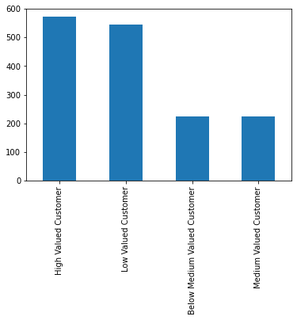

```
NOT Same Score                  4313
High Valued Customer             572
Low Valued Customer              545
Below Medium Valued Customer     225
Medium Valued Customer           223
Name: CustValue_Level, dtype: int64
```

```python
# Adding another column CustValue_Level to segment the customers in a way to show their value levels based on the RFM scores.
df_rfm["CustValue_Level"]=np.where((df_rfm['RecencyScore'] == 4) & (df_rfm['FrequencyScore'] == 4) & (df_rfm['MonetaryScore'] == 4) ,"High Valued Customer",
                               np.where((df_rfm['RecencyScore'] == 3) & (df_rfm['FrequencyScore'] == 3) & (df_rfm['MonetaryScore'] == 3) ,"Medium Valued Customer",
                                        np.where((df_rfm['RecencyScore'] == 2) & (df_rfm['FrequencyScore'] == 2) & (df_rfm['MonetaryScore'] == 2) ,"Below Medium Valued Customer",
                                                 np.where((df_rfm['RecencyScore'] == 1) & (df_rfm['FrequencyScore'] == 1) & (df_rfm['MonetaryScore'] == 1) ,"Low Valued Customer",
                                                          'NOT Same Score'))))
#Suggested segmentation of customers based on the same score of each RFM factor like 444, 333, 222 or 111
df_level_segments = df_rfm.loc[df_rfm['CustValue_Level'] !='NOT Same Score']
df_level_segments['CustValue_Level'].value_counts().plot(kind='bar')
plt.show()
#Check the number of each segment
print(df_rfm['CustValue_Level'].value_counts())
```

# Customized Segments

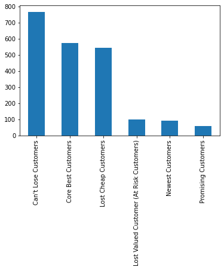

```
Not Segmented yet                           3744
Can't Lose Customers                         767
Core Best Customers                          572
Lost Cheap Customers                         545
Lost Valued Customer (At Risk Customers)     101
Newest Customers                              92
Promising Customers                           57
Name: Customized_seg, dtype: int64
```

```python
#Adding another column Customized_seg to segment the customers in a very deep and customized way with different conditions and different RFM scores for each
df_rfm['Customized_seg'] = np.where((df_rfm['RecencyScore'] == 4) & (df_rfm['FrequencyScore'] == 4) & (df_rfm['MonetaryScore'] == 4) ,"Core Best Customers",
                            np.where((df_rfm['FrequencyScore'] == 4) & ((df_rfm['MonetaryScore'] == 1) | (df_rfm['MonetaryScore'] == 2)) ,"Promising Customers",
                                     np.where((df_rfm['RecencyScore'] == 4) & (df_rfm['FrequencyScore'] == 1) ,"Newest Customers",
                                               np.where( ( (df_rfm['RecencyScore'] == 1) & (df_rfm['FrequencyScore'] == 4) & (df_rfm['MonetaryScore'] == 4) ) ,"Lost Valued Customer (At Risk Customers)",
                                                         np.where( ( (df_rfm['RecencyScore'] == 1) & (df_rfm['FrequencyScore'] == 3) & (df_rfm['MonetaryScore'] == 3) ) ,"Lost Valued Customer (At Risk Customers)",
                                                        np.where(( ( (df_rfm['RecencyScore'] == 1) | (df_rfm['RecencyScore'] == 2) ) & (df_rfm['FrequencyScore'] == 4)),"Can't Lose Customers",
                                                                 np.where(( ( (df_rfm['RecencyScore'] == 1) | (df_rfm['RecencyScore'] == 2) ) & (df_rfm['FrequencyScore'] == 3)),"Can't Lose Customers",
                                                                 np.where((df_rfm['RecencyScore'] == 1) & (df_rfm['FrequencyScore'] == 1) & (df_rfm['MonetaryScore'] == 1), 'Lost Cheap Customers',
                                               "Not Segmented yet"))))))))
#Suggested segmetation based on customized needs of business
df_custom_segments = df_rfm.loc[df_rfm['Customized_seg'] !='Not Segmented yet']
df_custom_segments['Customized_seg'].value_counts().plot(kind='bar')
plt.show()
#Check the number of each segment
print(df_rfm['Customized_seg'].value_counts())
```

# Suggested Marketing Strategies for different segments to direct marketing efforts efficently

## Core Best Customers

RFM Score: 444

**Who They Are:**

Highly engaged customers who have bought the most recent, the most often, and generated the most revenue.

**Marketing Strategies:**

Focus on loyalty programs and new product introductions. These customers have proven to have a higher willingness to pay, so don't use discount pricing to generate incremental sales. Instead, focus on value added offers through product recommendations based on previous purchases.

**For example:**

Uber targets their "core" RFM customer segment, introducing their new Uber Eats offering.

[figure not shown]

## Promising Customers

RFM Score: X42, X41

**Who They Are:**

Customers who return often, but do not spend a lot.

**Marketing Strategies:**

Focus on increasing monetization through product recommendations based on past purchases and incentives tied to spending thresholds.

**For example:**

This company pairs financial discounts with spending thresholds to drive repeat purchaes and increase customer profitability.

[figure not shown]

### Newest Customers

RFM Score: 41X

**Who They Are:**

First time buyers on your site.

**Marketing Strategies:**

Having clear strategies in place for first time buyers such as triggered welcome emails.

**For example:**

Starbucks use email to bring customers into their loyalty rewards program.

[figure not shown]

## Lost Valued Customer (At Risk Customers)

RFM Score: 144, 133

**Who They Are:**

customers who purchased often and spent big amounts, but haven’t purchased recently.

**Marketing Strategies:**

Send them personalized reactivation campaigns to reconnect, and offer renewals and helpful products to encourage another purchase.

## Can’t Lose Customers

RFM Score: 14x , 13x , 24x, 23x

**Who They Are:**

**(About to churn Customers)** customers who used to visit and purchase quite often, but haven’t been visiting recently.

**Marketing Strategies:**

Bring them back with relevant promotions, and run surveys to find out what went wrong and avoid losing them to a competitor.

## Lost Cheap Customers

RFM Score: 111

**Who They Are:**

Last purchase long ago, purchased few and spend little.

**Marketing Strategies:**

Don't spend too much trying to re-acquire.

# Segmentation of customers using K-means Clustering way

## we will divide the customers based on RFM values three times differently

### Two Segments, then Three Segments, and then Four Segments

### After each segmenting, we are going to see:

#### Summary Statistics for each cluster,

#### Relative importance of cluster attributes compared to population,

#### and a snake plot to notice the differences of RFM values between segments with different number of clusters

## checking for each one of the k-means assumptions

1 Symmetric distribution of each variable (Not Skewed)

2 Same Centering: all variabes have the same average values (so, each metric/variable has an equal weight in the k-means calculation)

3 Same Scaling: all variables have the same variance (scaling the variance of each variable to the same level)

**solutions**

- Skewness problem is resolved by logarithmatic transformation to each of the skewed variables (works only with positve valus) different averages and variances should be centered and scaled
- Applying a scaler from sklearn library to center and scale all three values

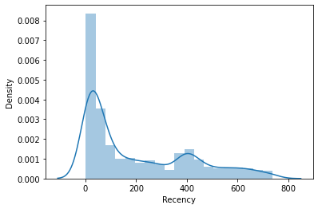

```python
#Import seaborn for visualization
import seaborn as sns
# Checking if the recency column is following normal distribution or is skewed
sns.distplot(df_rfm["Recency"])
plt.show();
```

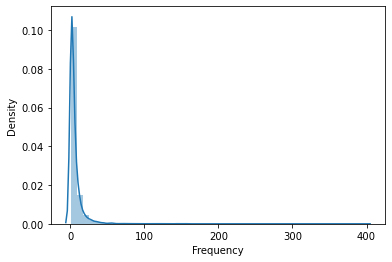

```python
# Checking if the Frequency column is following normal distribution or is skewed
sns.distplot(df_rfm["Frequency"])
plt.show();
```

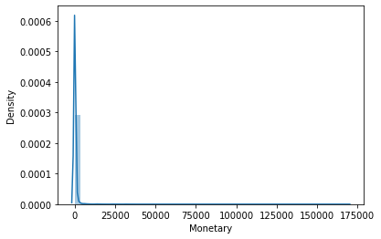

```python
# Checking if the Monetary column is following normal distribution or is skewed
sns.distplot(df_rfm["Monetary"])
plt.show();
```

```python
#Slicing only the RFM values to apply log transformationa and scaling on them.
rfm_values = df_rfm.iloc[:, [0, 2,3,4]]
rfm_values.set_index('Customer ID', inplace=True)
rfm_values.head();
```

```python
#Checking the average and the standard deviation of each RFM factor
rfm_values.describe();
```

```python
#applying logarithmatic transformation on each RFM factor
df_logged = np.log(rfm_values)
```

```python
# Centering and scaling the average and the variance/standard deviation respectively at the same time.
# Noteing that StandardScaler returns a numpy array

#importing the needed class from sklearn library
from sklearn.preprocessing import StandardScaler

#Initializing a scaler
scaler = StandardScaler()

#Fiting the scaler
scaler.fit(df_logged)

#Scaling and centering the data
rfm_normal = scaler.transform(df_logged)

# Create a pandas DataFrame after feature scalling
rfm_normal = pd.DataFrame(rfm_normal, index=rfm_values.index, columns=rfm_values.columns)

#Printing summary statistics
print(rfm_normal.describe().round(2))
```

```
       Recency  Frequency  Monetary
count  5878.00    5878.00   5878.00
mean     -0.00       0.00     -0.00
std       1.00       1.00      1.00
min      -2.78      -1.17     -6.92
25%      -0.74      -1.17     -0.73
50%       0.08      -0.10     -0.04
75%       0.95       0.72      0.63
max       1.36       4.65      4.87
```

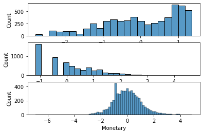

```python
# Plot recency distribution
plt.subplot(3, 1, 1); sns.histplot(rfm_normal['Recency'])

# Plot frequency distribution
plt.subplot(3, 1, 2); sns.histplot(rfm_normal['Frequency'])

# Plot monetary value distribution
plt.subplot(3, 1, 3); sns.histplot(rfm_normal['Monetary'])

# Show the plot
plt.show();
```

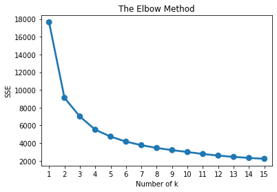

```python
#checking the optimum number of clusters
from sklearn.cluster import KMeans

sse = {}

# Fit KMeans and calculate SSE for each k
for k in range(1, 16):

    # Initialize KMeans with k clusters
    kmeans = KMeans(n_clusters=k, random_state=1)

    # Fit KMeans on the normalized dataset
    kmeans.fit(rfm_normal)

    # Assign sum of squared distances to k element of dictionary
    sse[k] = kmeans.inertia_

plt.title('The Elbow Method')
plt.xlabel('Number of k'); plt.ylabel('SSE')
sns.pointplot(x=list(sse.keys()), y=list(sse.values()))
plt.show();
```

# TWO Segments by K-means

```python
#divide the customers by only two segments based on RFM values using K-means algorithm

# Initialize KMeans
kmeans = KMeans(n_clusters=2, random_state=1)

# Fit k-means clustering on the normalized data set
kmeans.fit(rfm_normal)

# Extract cluster labels
cluster_labels = kmeans.labels_


# Create a DataFrame by adding a new cluster label column
rfm_k2 = rfm_values.assign(Cluster=cluster_labels)


# Calculate average RFM values and segment sizes per each cluster
rfm_k2.groupby(['Cluster']).agg({
    'Recency': 'mean',
    'Frequency': 'mean',
    'Monetary': ['mean', 'count']
  }).round(2)
```

| Cluster | Recency mean | Frequency mean | Monetary mean | Monetary count |
| --- | --- | --- | --- | --- |
| 0 | 307.28 | 1.99 | 50.31 | 3369 |
| 1 | 60.32 | 12.06 | 855.16 | 2509 |

```
         Recency  Frequency  Monetary
Cluster
0           0.52      -0.68     -0.87
1          -0.70       0.92      1.17
```

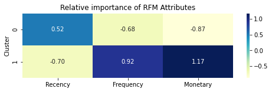

```python
#Creating the relative importance table for each RFM values based on Two segments.
cluster_avg = rfm_k2.groupby(['Cluster']).mean()
population_avg = rfm_values.mean()
relative_imp_k2 = cluster_avg / population_avg -1
print(relative_imp_k2.round(2))

# Plot heatmap of relative importance
plt.figure(figsize=(8, 2))
plt.title('Relative importance of RFM Attributes')
sns.heatmap(data=relative_imp_k2, annot=True, fmt='.2f', cmap='YlGnBu')
plt.show()
```

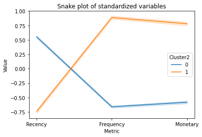

```python
#Adding a column Cluster2 to assign a cluster label for each row of the normalized rfm_normal
rfm_normal['Cluster2'] = rfm_k2['Cluster']

#for easier plotting in snake plot, we melt the data into a long format, so RFM values and metric names are stored in 1 column each
rfm_melt = pd.melt(rfm_normal.reset_index(),id_vars=['Customer ID','Cluster2'],
                        value_vars=['Recency','Frequency','Monetary'],var_name='Metric',value_name='Value')

#plotting the snake graph
plt.title('Snake plot of standardized variables')
sns.lineplot(x='Metric', y='Value', hue='Cluster2', data=rfm_melt)
plt.show();
```

# THREE Segments by K-means

```python
#divide the customers by only three segments based on RFM values using K-means algorithm

# Initialize KMeans
kmeans = KMeans(n_clusters=3, random_state=1)

# Fit k-means clustering on the normalized data set
kmeans.fit(rfm_normal)

# Extract cluster labels
cluster_labels = kmeans.labels_


# Create a DataFrame by adding a new cluster label column
rfm_k3 = rfm_values.assign(Cluster=cluster_labels)


# Calculate average RFM values and segment sizes per each cluster
rfm_k3.groupby(['Cluster']).agg({
    'Recency': 'mean',
    'Frequency': 'mean',
    'Monetary': ['mean', 'count']
  }).round(2)
```

| Cluster | Recency mean | Frequency mean | Monetary mean | Monetary count |
| --- | --- | --- | --- | --- |
| 0 | 31.12 | 17.20 | 1342.19 | 1421 |
| 1 | 353.82 | 1.45 | 28.14 | 2374 |
| 2 | 145.17 | 4.36 | 163.72 | 2083 |

```
         Recency  Frequency  Monetary
Cluster
0          -0.85       1.74      2.41
1           0.75      -0.77     -0.93
2          -0.28      -0.31     -0.58
```

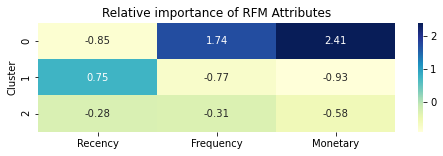

```python
#Creating the relative importance table for each RFM values based on Three segments.
cluster_avg = rfm_k3.groupby(['Cluster']).mean()
population_avg = rfm_values.mean()
relative_imp_k3 = cluster_avg / population_avg -1
print(relative_imp_k3.round(2))

# Plot heatmap of relative importance
plt.figure(figsize=(8, 2))
plt.title('Relative importance of RFM Attributes')
sns.heatmap(data=relative_imp_k3, annot=True, fmt='.2f', cmap='YlGnBu')
plt.show();
```

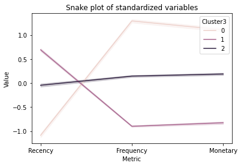

```python
#Adding a column Cluster3 to assign a cluster label for each row of the normalized rfm_normal
rfm_normal['Cluster3'] = rfm_k3['Cluster']

#for easier plotting in snake plot, we melt the data into a long format, so RFM values and metric names are stored in 1 column each
rfm_melt = pd.melt(rfm_normal.reset_index(),id_vars=['Customer ID','Cluster3'],
                        value_vars=['Recency','Frequency','Monetary'],var_name='Metric',value_name='Value')

#plotting the snake graph
plt.title('Snake plot of standardized variables')
sns.lineplot(x='Metric', y='Value', hue='Cluster3', data=rfm_melt)
plt.show();
```

# FOUR Segments by K-means

```python
#divide the customers by only four segments based on RFM values using K-means algorithm


# Initialize KMeans
kmeans = KMeans(n_clusters=4, random_state=1)

# Fit k-means clustering on the normalized data set
kmeans.fit(rfm_normal)

# Extract cluster labels
cluster_labels = kmeans.labels_


# Create a DataFrame by adding a new cluster label column
rfm_k4 = rfm_values.assign(Cluster=cluster_labels)


# Calculate average RFM values and segment sizes per each cluster
rfm_k4.groupby(['Cluster']).agg({
    'Recency': 'mean',
    'Frequency': 'mean',
    'Monetary': ['mean', 'count']
  }).round(2)
```

| Cluster | Recency mean | Frequency mean | Monetary mean | Monetary count |
| --- | --- | --- | --- | --- |
| 0 | 218.07 | 4.98 | 228.85 | 1278 |
| 1 | 31.14 | 17.21 | 1343.10 | 1420 |
| 2 | 28.17 | 3.14 | 54.64 | 920 |
| 3 | 370.68 | 1.45 | 28.83 | 2260 |

```
         Recency  Frequency  Monetary
Cluster
0           0.08      -0.21     -0.42
1          -0.85       1.74      2.41
2          -0.86      -0.50     -0.86
3           0.84      -0.77     -0.93
```

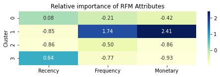

```python
#Creating the relative importance table for each RFM values based on Four segments.
cluster_avg = rfm_k4.groupby(['Cluster']).mean()
population_avg = rfm_values.mean()
relative_imp_k4 = cluster_avg / population_avg -1
print(relative_imp_k4.round(2))

# Plot heatmap of relative importance
plt.figure(figsize=(8, 2))
plt.title('Relative importance of RFM Attributes')
sns.heatmap(data=relative_imp_k4, annot=True, fmt='.2f', cmap='YlGnBu')
plt.show();
```

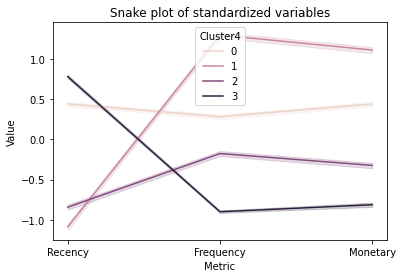

```python
#Adding a column Cluster4 to assign a cluster label for each row of the normalized rfm_normal
rfm_normal['Cluster4'] = rfm_k4['Cluster']

#for easier plotting in snake plot, we melt the data into a long format, so RFM values and metric names are stored in 1 column each
rfm_melt = pd.melt(rfm_normal.reset_index(),id_vars=['Customer ID','Cluster4'],
                        value_vars=['Recency','Frequency','Monetary'],var_name='Metric',value_name='Value')

#plotting the snake graph
plt.title('Snake plot of standardized variables')
sns.lineplot(x='Metric', y='Value', hue='Cluster4', data=rfm_melt)
plt.show();
```

## It seems that clustering with different number of segments can give different insights. So, I think there's no right or wrong number of segments, but there's a better number of segments.

## The best decision to make here is to consult the person with the domain business knowledge and let them see which number of segments is more suitable for the business needs.

```python
df_rfm.to_csv('df-rfm.csv')
df_filtered.to_csv('df-filtered.csv')
```